# Occupancy simulation

Deon Roos

Script last run on 2021-11-05

```r
library(tidyverse)
library(patchwork)
library(reshape2)
library(emon)
```

# Occupancy models

- Occupancy models are only concerned with whether or not a species presence or absence from a number of sites. There may be a single individual of the species present or millions of them. In occupancy models, we do not care how many there are, only if at least one individual of the species is present or not.
- There are two very broad forms of occupancy models. The first is a multi-season occupancy model, which assumes closure during the sampling period, while the system can be open between primary periods (e.g., years). This is the form of the model the students will use to analyse the data contained herein.
- The other form is a single season occupancy model, where data is collected during a single primary period (e.g., the field season of 2013). These models only estimate detection probability and occupancy probability. The students learn about this method, but will not use it.
- Both forms of occupancy models use surveys in multiple locations (called “sites” in this document). As such, occupancy models can be considered “species distribution models” (SDMs), but note that SDMs are more generally just simple Poisson (number of animals) or Binomial (animal presence/absence) GLMs, where detection probabilities are not considered (or they simply assume that if the species was never found, it was because they were never there).
- Both forms of occupancy models require multiple surveys per primary period (i.e., three surveys per field season, where single season occupancy models only have a single field season). Any detections of the species in one survey implies that it was always present, regardless if you detected it or not on the other two surveys.
- As such, there is a strong assumption of closure at the site level during a sampling period, i.e., if the species is present at one survey, it was always present.
- Instances where the species is detected in only some of the surveys, in a given site, helps to calibrate detection probabilities (e.g., if you find an animal in one survey out of three, then your detection probability is 33%).
- For multi-season occupancy models (referred to simply as “occupancy models” hereafter), because the data consists of multiple primary periods, the model considers that the time between primary periods to be open, meaning that from one year to the next a site can go from occupied to unoccupied.
- Occupancy models assume, and account for, *imperfect detection*.

## Estimated parameters

There are four core parameters estimated in multi-season occupancy models:

### Initial occupancy probability

- $\psi_1$ (psi) is the initial occupancy probability, i.e., what is the probability that the site was occupied in the **first primary period only**.

### Colonisation probability

- $\gamma$ (gamma) is the colonisation probability, and is conditional on the site having been unoccupied in the previous primary period (the species need to be absent from the site in the previous year in order for the site to be colonised in the subsequent year).

### Extinction probability

- $\epsilon$ (epsilon) is the extinction probability, and is conditional on the site having been occupied (the species needs to be present from the site in the previous year in order for the site to go locally extinct in the subsequent year).

### Detection probability

- $p$ is the detection probability, and is conditional on the being occupied (the animal needs to be present in the site in order for you to be able to detect it). This means that false negatives are positive (i.e., you can fail to detect the animal), but false positives are not positive (i.e., you cannot detect the animal if it is not present).

All of these parameters can themselves be influenced by covariates. If they are modelled as such, these relationships take the form of Binomial GLMs (i.e., $logit(parameter_i) = \beta_0 + \beta_1X_i$). As such, an occupancy models may have multiple sub-models, each with their own parameters.

## Derived parameters

### Occupancy probability

The following parameters are not directly estimated in the model, but are derived based on the parameters which are estimated. These parameters include:

- $\psi_{i,t}$ is the probability that a site ($i$) was occupied in a given primary periods ($t$, e.g., year).
- Within this code, $\Pi_{i,t}$ is simulated as:

$\Pi_{i,t} = Binomial(\psi_{i,t})$

$$\begin{equation}
\psi_{i,t} =
\begin{cases}
\Pi_{i, t-1} = 0, & \gamma_{i,t} \\
\Pi_{i, t-1} = 1, & (1 - \epsilon_{i,t})
\end{cases}
\end{equation}$$

which can be read as; the probability that a site is occupied in a given year ($\psi_{i,t}$), depends on the true occupancy in the previous primary period ($\Pi_{i,t-1}$). When the species were previously absent ($\Pi_{i,t-1} = 0$), then it may be colonised ($\gamma_{i,t}$), while if the species were previously present ($\Pi_{i,t-1} = 1$), then it may fail to go extinct ($(1 - \epsilon_{i,t})$). Note that the { bracket is the equivalent to an if statement (e.g., if a site is occupied (1) then do this, or if a site is unoccupied (0) then do that).

- While this is how the data is simulated, this is not useful for the model because the true presence is not know ($\Pi$). We only know that here because I simulate the data.
- As such, this process is modelled as : $\psi_{i, t+1} = \psi_{i,t}(1 - \epsilon_{i,t}) + (1 - \psi_{i,t})\gamma_{i,t}$, which reads essentially the same as the above, except that it uses the probability of presence ($\psi_{i,t}$) rather than true occupancy ($\Pi_{i,t}$).

# Details of the dataset

- This dataset is interested in the dynamics on a non-native invasive species, the Java mongoose.
- Mongoose were intentionally introduced to the island in ca. 1979 in order to deal with the Habu snake. The Habu snake occasionally bite people, and the venom can be lethal (though rarely).
- The island relies on tourism, in part driven by tourists coming to see the endemic Amami rabbit. The rabbits split off from the mainland rabbit population millions of years ago.
- Not long after introducing the mongoose, it became clear that they were a severe threat to the rabbits.
- An organisation, called “Mongoose Busters” was started to tackle the mongoose.
- This data is meant to provide the students with an understanding of the current situation with the Java mongoose, and to use the results herein to make any recommendations for their continued management.
- Note, in the real world, I think the mongoose were eradicated from the island last year. These simulations are therefore an alternative reality.

## Changes to simulation from last year

- I have increased the sample size dramatically. Last year I tried to keep sample sizes fairly realistic, but this lead to issues where models could not be fit.
- There is a trade-off between maintaining realism and teaching, but I think this year I favour teaching, so I increased sample sizes.
- There is an additional variable this year - sniffer dogs - which I have stolen from a students report from last year (look adaptive management in action!!!).

# Simulation

## Initial values

Some of the values are used throughout the simulation, and as such are specified here.

```r
# Number of regions (increased from last year's 7)
n_region <- 15

# Number of sites in each region
n_site <- 5

# Years when surveying took place
survey_years <- seq(1987, 2022, by = 1)

# Total number of years
n_year <- length(survey_years)
```

The sample design has 15 regions, within each there are 5 sites where mongoose surveys occur. The data is collected from 1987 to 2022, but note that surveys may or may not occur every year. This is decided later in the document.

## Initial arrays

The following code creates empty arrays (arrays are 3-dimensional datasets or “stacked” matrices) to later populate with values for the various occupancy dynamics and parameters.

```r
# With dimensions [Year, Site, Region]
occupancy <- array(0, dim = c(nrow = n_year, ncol = n_site, n_region))
rownames(occupancy) <- c(survey_years)

colonise_p <- array(0, dim = c(nrow = n_year, ncol = n_site, n_region))
extinct_p <- array(0, dim = c(nrow = n_year, ncol = n_site, n_region))
presence_p <- array(0, dim = c(nrow = n_year, ncol = n_site, n_region))
```

# Simulating covariates

## Amami rabbits

For each location ($i$), in each year ($t$), rabbit presence in the first year is determined by:

$Rabbit_{i,1} = binomial(p_{i,1}), logit(p_{i,1}) = 1.1$

Subsequent rabbit presence depends on if there were rabbits present in the previous year, however if there were no rabbits in $t-1$, then there is a 15% chance for rabbits to appear:

$Rabbit_{i,t} = binomial(p_{i,t})$

$logit(p_{i,t}) = -1.74 + Rabbit_{i,t-1} \times 3$

### Simulation

```r
set.seed(666)
# Array with [Year, Site, Region]
rabbit <- array(0, dim = c(nrow = n_year, ncol = n_site, n_region))
# Year as row name
rownames(rabbit) <- c(survey_years) # 20 years

# Initial probability that a site has rabbits present = 75%
rabbit[1, , ] <- rbinom(n = n_site * n_region, size = 1, prob = plogis(1.1))


for(t in 2:n_year){
  for(i in 1:n_region){
    for(s in 1:n_site) {
      rabbit[t, s, i] <- rbinom(1, 1, prob = plogis(-1.74 + rabbit[t-1, s, i] * 3))
    }
  }
}
```

### Data

```r
rabbit_df <- as.data.frame(t(as.data.frame(rabbit)))

sites_id <- rep(letters[1:5], n_region)

# The names of the 15 regions
region_id <- c(rep("Edateku", n_site), rep("Oshima", n_site), rep("Kakeromajima", n_site), rep("Ukejima", n_site), rep("Yoroshima", n_site),
               rep("Tatsugo", n_site), rep("Kikai", n_site), rep("Setouchi", n_site), rep("Uken", n_site), rep("Yamato", n_site),
               rep("Katetsu", n_site), rep("Kinsakubaru", n_site), rep("Naze", n_site), rep("Gunto", n_site), rep("Tokunoshima", n_site))

seq_names <- paste(region_id, sites_id, sep = " ")

rownames(rabbit_df)[1:length(seq_names)] <- seq_names

rabbit_df$site <- factor(rownames(rabbit_df))
rabbit_df
```

|  | 1987 | 1988 | 1989 | 1990 | 1991 | 1992 | 1993 | 1994 | 1995 | 1996 | 1997 | 1998 | 1999 | 2000 | 2001 | 2002 | 2003 | 2004 | 2005 | 2006 | 2007 | 2008 | 2009 | 2010 | 2011 | 2012 | 2013 | 2014 | 2015 | … |
| --- | --- | --- | --- | --- | --- | --- | --- | --- | --- | --- | --- | --- | --- | --- | --- | --- | --- | --- | --- | --- | --- | --- | --- | --- | --- | --- | --- | --- | --- | --- |
| Edateku a | 0 | 0 | 0 | 0 | 0 | 0 | 0 | 0 | 0 | 0 | 0 | 0 | 0 | 0 | 0 | 0 | 0 | 0 | 0 | 0 | 0 | 0 | 0 | 0 | 1 | 0 | 0 | 1 | 1 | … |
| Edateku b | 1 | 1 | 1 | 1 | 1 | 1 | 0 | 0 | 0 | 1 | 1 | 0 | 0 | 0 | 0 | 0 | 1 | 1 | 1 | 0 | 0 | 0 | 0 | 0 | 0 | 1 | 1 | 1 | 0 | … |
| Edateku c | 0 | 0 | 0 | 0 | 0 | 0 | 1 | 1 | 1 | 0 | 0 | 0 | 0 | 0 | 0 | 0 | 0 | 0 | 0 | 0 | 0 | 0 | 0 | 1 | 1 | 1 | 1 | 1 | 0 | … |
| Edateku d | 1 | 0 | 0 | 0 | 0 | 0 | 0 | 0 | 0 | 0 | 0 | 0 | 0 | 1 | 1 | 1 | 1 | 1 | 1 | 1 | 0 | 0 | 0 | 0 | 0 | 0 | 0 | 0 | 0 | … |
| Edateku e | 1 | 0 | 0 | 0 | 0 | 0 | 0 | 0 | 0 | 0 | 0 | 0 | 0 | 0 | 0 | 0 | 0 | 0 | 1 | 1 | 0 | 0 | 0 | 0 | 0 | 0 | 0 | 0 | 0 | … |
| Oshima a | 1 | 1 | 1 | 0 | 1 | 0 | 0 | 0 | 0 | 0 | 0 | 0 | 0 | 1 | 1 | 1 | 1 | 0 | 0 | 0 | 0 | 0 | 1 | 0 | 1 | 0 | 0 | 1 | 0 | … |
| Oshima b | 0 | 0 | 0 | 0 | 0 | 1 | 1 | 1 | 1 | 1 | 1 | 1 | 1 | 1 | 1 | 1 | 1 | 1 | 1 | 1 | 1 | 0 | 0 | 0 | 0 | 0 | 0 | 0 | 1 | … |
| Oshima c | 1 | 1 | 1 | 1 | 0 | 0 | 0 | 0 | 0 | 0 | 0 | 0 | 0 | 0 | 0 | 0 | 0 | 0 | 0 | 0 | 1 | 1 | 1 | 1 | 1 | 1 | 1 | 1 | 1 | … |
| Oshima d | 1 | 0 | 0 | 1 | 1 | 1 | 1 | 1 | 1 | 1 | 1 | 1 | 1 | 1 | 1 | 1 | 1 | 1 | 1 | 0 | 0 | 0 | 0 | 0 | 0 | 1 | 1 | 0 | 0 | … |
| Oshima e | 1 | 1 | 1 | 1 | 1 | 1 | 0 | 0 | 0 | 1 | 1 | 0 | 0 | 0 | 1 | 0 | 0 | 0 | 0 | 0 | 0 | 0 | 0 | 0 | 0 | 0 | 0 | 0 | 0 | … |

[output cut: 65 more lines]

### Figure

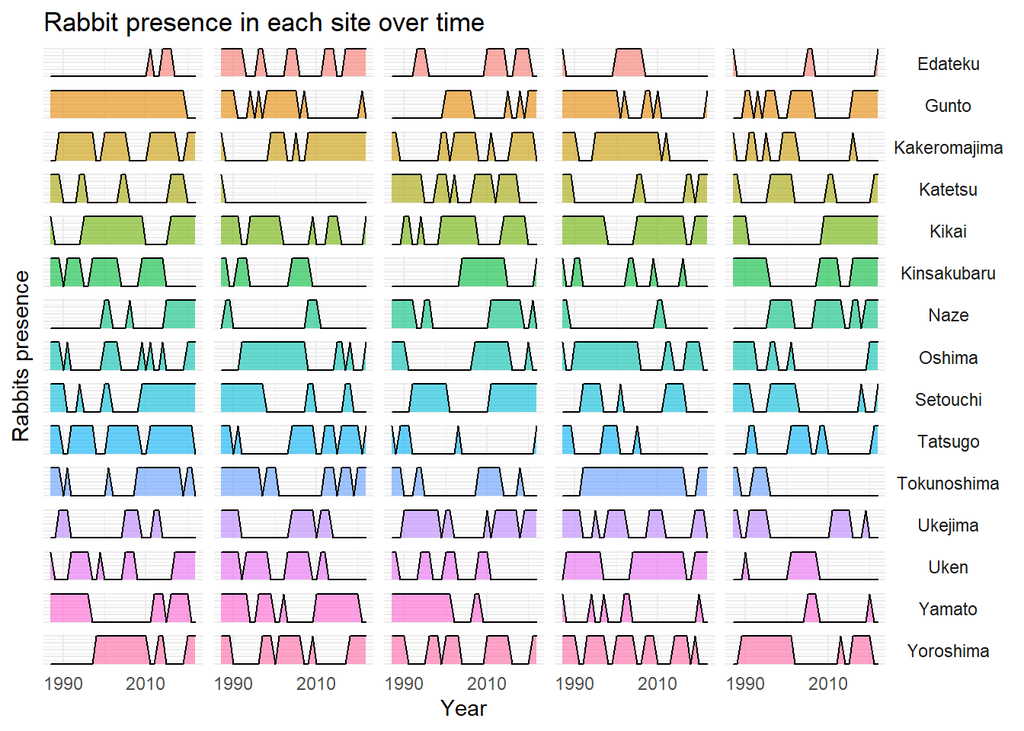

```r
rabbit_plot <- melt(rabbit_df, id="site" )

rabbit_plot$region <- str_split(rabbit_plot$site, pattern = " ", simplify = TRUE)[,1]
rabbit_plot$location <- str_split(rabbit_plot$site, pattern = " ", simplify = TRUE)[,2]

rabbit_plot$year <- as.numeric(as.character(rabbit_plot$variable))

ggplot(rabbit_plot) +
  geom_area(aes(x = year, y = value, fill = region, group = location),
            show.legend = FALSE, alpha = 0.6, colour = "black") +
  labs(x = "Year",
       y = "Rabbits presence",
       fill = "Region",
       title = "Rabbit presence in each site over time") +
  facet_grid(region ~ location) +
  scale_x_continuous(breaks = c(1990, 2010)) +
  theme_bw() +
  theme_minimal() +
  theme(axis.text.y = element_blank(),
        axis.ticks.y = element_blank(),
        strip.text.x = element_blank(),
        strip.text.y = element_text(angle = 360))
```

## Human distance

Human distance is generated according to a log Normal distribution, with a declining trend ($\alpha_1$), but each site has it’s own intercept and slope (somewhat analogous to a random effect).

$\alpha_0 \sim logNormal(3.9, 0.3)$

$Human_i \sim logNormal(\mu_i, 0.1)$

$log(\mu_i) = \alpha_0 + \alpha_1 \times Year_i$

### Simulation

```r
set.seed(666)

# Array with [Year, Site, Region]
human <- array(0, dim = c(nrow = n_year, ncol = n_site, n_region))

a0 <- rlnorm(1, mean = 3.3, sd = 0.5)
a1 <- rnorm(1, mean = -5, sd = 2)

for(s in 1:n_site){
  for(r in 1:n_region) {
    a0 <- rlnorm(1, mean = 3.9, sd = 0.3)
    a1 <- rnorm(1, mean = -0.5, sd = 0.2)
    human[, s, r] <- rlnorm(n_year, mean = log(a0 + a1 * 1:n_year), sd = 0.1)
  }
}
```

### Data

```r
human_df <- as.data.frame(t(as.data.frame(human)))

rownames(human_df)[1:length(seq_names)] <- seq_names
colnames(human_df) <- colnames(rabbit_df[,-37])

human_df$site<-factor(rownames(human_df))
human_df
```

|  | 1987 | 1988 | 1989 | 1990 | 1991 | 1992 | 1993 | 1994 | 1995 | 1996 | 1997 | 1998 | 1999 | 2000 | 2001 | 2002 | 2003 | 2004 | 2005 | 2006 | 2007 | 2008 | 2009 | 2010 | 2011 | 2012 | 2013 | 2014 | 2015 | … |
| --- | --- | --- | --- | --- | --- | --- | --- | --- | --- | --- | --- | --- | --- | --- | --- | --- | --- | --- | --- | --- | --- | --- | --- | --- | --- | --- | --- | --- | --- | --- |
| Edateku a | 35.50399 | 47.70520 | 38.72348 | 40.63671 | 36.72854 | 43.65968 | 54.24321 | 36.57230 | 47.49458 | 36.59699 | 43.95739 | 42.95046 | 47.05312 | 44.60070 | 40.56160 | 46.40870 | 39.94317 | 37.94571 | 48.38230 | 41.21396 | 42.55799 | 36.501609 | 37.73875 | 35.329960 | 37.811457 | 36.683516 | 45.144811 | 39.172307 | 48.085001 | … |
| Edateku b | 57.65374 | 63.87627 | 64.41648 | 49.28755 | 68.61422 | 52.82551 | 67.63802 | 61.35871 | 58.10894 | 61.75450 | 56.21217 | 59.05862 | 66.89134 | 56.52234 | 52.58236 | 47.24023 | 51.30622 | 46.26058 | 47.72304 | 45.25686 | 50.75626 | 47.934126 | 45.61285 | 41.013747 | 40.889530 | 41.212474 | 43.170851 | 45.743038 | 37.676904 | … |
| Edateku c | 42.18338 | 39.78887 | 35.00033 | 30.98617 | 36.61721 | 33.20961 | 31.11779 | 36.33102 | 32.83992 | 29.58602 | 36.80006 | 32.94821 | 29.41444 | 33.54858 | 35.84183 | 35.00411 | 33.22748 | 29.54876 | 28.78453 | 31.39760 | 30.38137 | 28.169107 | 28.34857 | 27.656528 | 31.809692 | 32.129863 | 29.885752 | 36.145658 | 28.540346 | … |
| Edateku d | 23.27211 | 25.67625 | 22.69323 | 20.63265 | 24.17665 | 20.56951 | 19.64961 | 25.94783 | 18.49490 | 16.13488 | 19.11488 | 16.47796 | 18.44108 | 14.92822 | 14.94711 | 16.41640 | 12.46327 | 12.57967 | 10.92882 | 14.11475 | 13.16281 | 9.699647 | 10.53693 | 7.777481 | 7.163143 | 6.729994 | 5.463513 | 6.086402 | 5.780329 | … |
| Edateku e | 46.81042 | 48.48922 | 56.89740 | 49.81168 | 48.51599 | 52.45109 | 52.15534 | 57.12552 | 58.37984 | 47.35912 | 48.46079 | 53.85693 | 43.25408 | 39.83801 | 45.49408 | 43.67794 | 53.17677 | 48.05888 | 43.74007 | 41.29387 | 45.22310 | 40.958793 | 40.20660 | 45.300170 | 39.310519 | 41.727996 | 39.213961 | 41.860253 | 43.969572 | … |
| Oshima a | 57.94464 | 72.42725 | 62.77715 | 52.79904 | 56.64357 | 58.36131 | 61.04137 | 58.79780 | 57.15478 | 62.39325 | 51.13044 | 51.05062 | 51.00053 | 48.86776 | 51.22646 | 48.01129 | 55.08135 | 57.57428 | 45.32428 | 45.17706 | 42.82905 | 58.567549 | 51.01276 | 45.213833 | 47.343277 | 47.746664 | 53.367867 | 44.402892 | 42.708990 | … |
| Oshima b | 56.02822 | 51.01171 | 48.23860 | 48.44045 | 46.00560 | 47.27714 | 52.37292 | 44.68037 | 45.11685 | 53.72951 | 45.68598 | 52.03752 | 45.91285 | 46.17058 | 50.74714 | 40.06126 | 39.94901 | 51.04195 | 46.60273 | 47.46078 | 40.76106 | 40.882874 | 49.09461 | 35.959473 | 41.524338 | 36.738799 | 33.421773 | 33.824214 | 42.507365 | … |
| Oshima c | 54.96581 | 46.58056 | 52.26575 | 40.37531 | 48.37400 | 44.28825 | 43.54351 | 46.00705 | 36.09080 | 48.25891 | 44.54325 | 37.63674 | 43.15408 | 35.84542 | 46.05692 | 38.33226 | 40.62712 | 42.40331 | 38.32154 | 36.27939 | 34.99389 | 40.730026 | 34.40678 | 35.461031 | 33.721416 | 36.106991 | 35.750952 | 39.291477 | 30.695275 | … |
| Oshima d | 27.58755 | 34.72559 | 31.88072 | 26.32812 | 24.67771 | 27.66679 | 26.31958 | 26.36812 | 23.78330 | 25.19403 | 21.30488 | 28.86111 | 20.62940 | 18.39006 | 20.39283 | 20.02893 | 19.25222 | 16.48811 | 20.97693 | 16.90344 | 15.37492 | 16.766018 | 16.03050 | 13.722878 | 13.046531 | 12.630359 | 10.864394 | 11.358298 | 10.713780 | … |
| Oshima e | 62.34875 | 72.72592 | 61.53857 | 58.07438 | 59.95027 | 58.46729 | 61.94320 | 59.12831 | 46.10556 | 52.80097 | 51.81442 | 56.38104 | 51.62344 | 47.19587 | 51.32897 | 50.09473 | 55.18420 | 44.88934 | 44.10139 | 45.46811 | 47.13760 | 48.443561 | 50.27204 | 45.174319 | 54.230706 | 45.692228 | 39.608156 | 37.205601 | 48.723617 | … |

[output cut: 65 more lines]

### Figure

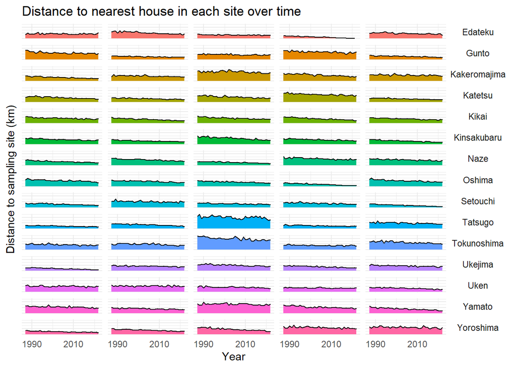

```r
human_plot <- melt(human_df, id="site" )

human_plot$region <- str_split(human_plot$site, pattern = " ", simplify = TRUE)[,1]
human_plot$location <- str_split(human_plot$site, pattern = " ", simplify = TRUE)[,2]

human_plot$year <- as.numeric(as.character(human_plot$variable))

ggplot(human_plot) +
  geom_area(aes(x = year, y = value, fill = region),
            show.legend = FALSE, colour = "black") +
  labs(x = "Year",
       y = "Distance to sampling site (km)",
       colour = "Region",
       title = "Distance to nearest house in each site over time") +
  scale_x_continuous(breaks = c(1990, 2010)) +
  scale_y_continuous(n.breaks = 3) +
  facet_grid(region ~ location) +
  theme_bw() +
  theme_minimal() +
  theme(axis.text.y = element_blank(),
        axis.ticks.y = element_blank(),
        strip.text.x = element_blank(),
        strip.text.y = element_text(angle = 360))
```

## Mongoose control

Mongoose control start date is random for each region, beginning from the fifth year up to six years before the end of the surveying period. Within a given region, individual sites may start on the regional start year, or up to six years later

### Simulation

```r
set.seed(666)
# Array with [Year, Site, Region]
buster <- array(0, dim = c(nrow = n_year, ncol = n_site, n_region))

region_start <- round(runif(n_region, 5, n_year - 6), digit = 0)

for(i in 1:n_region){
  for(s in 1:n_site) {
    site_start <- region_start[i] + round(runif(1, 0, 6), digit = 0)
    buster[site_start:n_year, s, i] <- 1
  }
}
```

### Data

```r
buster_df <- as.data.frame(t(as.data.frame(buster)))

rownames(buster_df)[1:length(seq_names)] <- seq_names
colnames(buster_df) <- colnames(human_df[,-37])

buster_df$site <- factor(rownames(buster_df))
buster_df
```

|  | 1987 | 1988 | 1989 | 1990 | 1991 | 1992 | 1993 | 1994 | 1995 | 1996 | 1997 | 1998 | 1999 | 2000 | 2001 | 2002 | 2003 | 2004 | 2005 | 2006 | 2007 | 2008 | 2009 | 2010 | 2011 | 2012 | 2013 | 2014 | 2015 | … |
| --- | --- | --- | --- | --- | --- | --- | --- | --- | --- | --- | --- | --- | --- | --- | --- | --- | --- | --- | --- | --- | --- | --- | --- | --- | --- | --- | --- | --- | --- | --- |
| Edateku a | 0 | 0 | 0 | 0 | 0 | 0 | 0 | 0 | 0 | 0 | 0 | 0 | 0 | 0 | 0 | 0 | 0 | 0 | 0 | 0 | 0 | 0 | 0 | 0 | 0 | 0 | 0 | 0 | 1 | … |
| Edateku b | 0 | 0 | 0 | 0 | 0 | 0 | 0 | 0 | 0 | 0 | 0 | 0 | 0 | 0 | 0 | 0 | 0 | 0 | 0 | 0 | 0 | 0 | 0 | 1 | 1 | 1 | 1 | 1 | 1 | … |
| Edateku c | 0 | 0 | 0 | 0 | 0 | 0 | 0 | 0 | 0 | 0 | 0 | 0 | 0 | 0 | 0 | 0 | 0 | 0 | 0 | 0 | 0 | 0 | 0 | 0 | 0 | 0 | 0 | 0 | 1 | … |
| Edateku d | 0 | 0 | 0 | 0 | 0 | 0 | 0 | 0 | 0 | 0 | 0 | 0 | 0 | 0 | 0 | 0 | 0 | 0 | 0 | 0 | 0 | 0 | 0 | 0 | 0 | 0 | 1 | 1 | 1 | … |
| Edateku e | 0 | 0 | 0 | 0 | 0 | 0 | 0 | 0 | 0 | 0 | 0 | 0 | 0 | 0 | 0 | 0 | 0 | 0 | 0 | 0 | 0 | 0 | 0 | 0 | 0 | 0 | 1 | 1 | 1 | … |
| Oshima a | 0 | 0 | 0 | 0 | 0 | 0 | 0 | 0 | 0 | 0 | 0 | 0 | 0 | 0 | 0 | 1 | 1 | 1 | 1 | 1 | 1 | 1 | 1 | 1 | 1 | 1 | 1 | 1 | 1 | … |
| Oshima b | 0 | 0 | 0 | 0 | 0 | 0 | 0 | 0 | 0 | 0 | 0 | 0 | 0 | 1 | 1 | 1 | 1 | 1 | 1 | 1 | 1 | 1 | 1 | 1 | 1 | 1 | 1 | 1 | 1 | … |
| Oshima c | 0 | 0 | 0 | 0 | 0 | 0 | 0 | 0 | 0 | 1 | 1 | 1 | 1 | 1 | 1 | 1 | 1 | 1 | 1 | 1 | 1 | 1 | 1 | 1 | 1 | 1 | 1 | 1 | 1 | … |
| Oshima d | 0 | 0 | 0 | 0 | 0 | 0 | 0 | 0 | 0 | 0 | 1 | 1 | 1 | 1 | 1 | 1 | 1 | 1 | 1 | 1 | 1 | 1 | 1 | 1 | 1 | 1 | 1 | 1 | 1 | … |
| Oshima e | 0 | 0 | 0 | 0 | 0 | 0 | 0 | 0 | 0 | 0 | 0 | 0 | 0 | 0 | 1 | 1 | 1 | 1 | 1 | 1 | 1 | 1 | 1 | 1 | 1 | 1 | 1 | 1 | 1 | … |

[output cut: 65 more lines]

### Figure

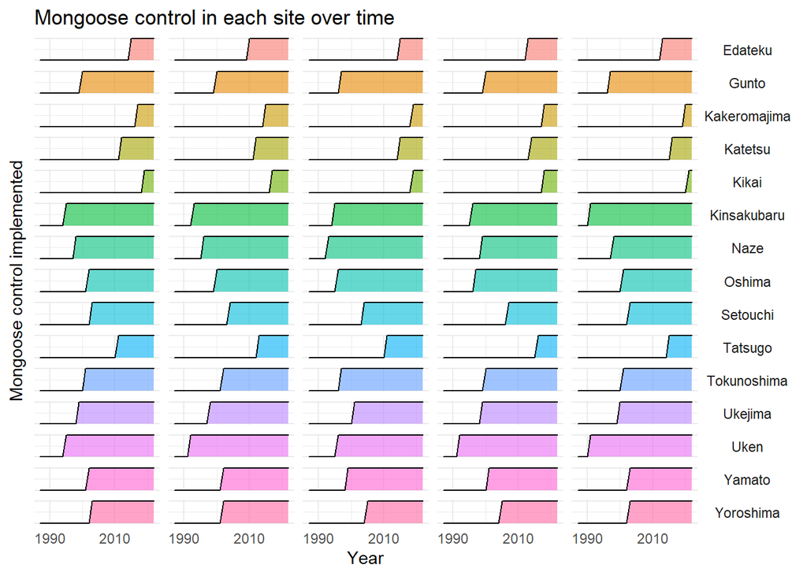

```r
buster_plot <- melt(buster_df, id="site" )

buster_plot$region <- str_split(buster_plot$site, pattern = " ", simplify = TRUE)[,1]
buster_plot$location <- str_split(buster_plot$site, pattern = " ", simplify = TRUE)[,2]

buster_plot$year <- as.numeric(as.character(buster_plot$variable))

ggplot(buster_plot) +
  geom_area(aes(x = year, y = value, fill = region, group = location),
            show.legend = FALSE, alpha = 0.6, colour = "black") +
  labs(x = "Year",
       y = "Mongoose control implemented",
       fill = "Region",
       colour = "Region",
       title = "Mongoose control in each site over time") +
  facet_grid(region ~ location) +
  scale_y_continuous(breaks = c(0, 1)) +
  scale_x_continuous(breaks = c(1990, 2010)) +
  theme_bw() +
  theme_minimal() +
  theme(axis.text.y = element_blank(),
        axis.ticks.y = element_blank(),
        strip.text.x = element_blank(),
        strip.text.y = element_text(angle = 360))
```

## Habu snake

For each location ($i$), in each year ($t$), Habu snake presence in the first year is determined by:

$Snake_{i,1} = binomial(p_{i,1}), logit(p_{i,1}) = -1.74$

Subsequent snake presence is mostly temporally autocorrelated, but if there were no snakes in $t-1$, then there is a 5% chance for snakes to appear:

$Snake_{i,t} = binomial(p_{i,t})$

$logit(p_{i,t}) = -2.9 + Snake_{i,t-1} \times 3.6$

### Simulation

```r
set.seed(666)
# Array with [Year, Site, Region]
snake <- array(0, dim = c(nrow = n_year, ncol = n_site, n_region))

snake[1, , ] <- rbinom(n = n_site * n_region, size = 1, prob = plogis(-1.74))

for(t in 2:n_year){
  for(i in 1:n_region){
    for(s in 1:n_site) {
      snake[t, s, i] <- rbinom(1, 1, prob = plogis(-2.9 + snake[t-1, s, i] * 3.6))
    }
  }
}
```

### Data

```r
snake_df <- as.data.frame(t(as.data.frame(snake)))

rownames(snake_df)[1:length(seq_names)] <- seq_names
colnames(snake_df) <- colnames(human_df[,-37])

snake_df$site <- factor(rownames(snake_df))
snake_df
```

|  | 1987 | 1988 | 1989 | 1990 | 1991 | 1992 | 1993 | 1994 | 1995 | 1996 | 1997 | 1998 | 1999 | 2000 | 2001 | 2002 | 2003 | 2004 | 2005 | 2006 | 2007 | 2008 | 2009 | 2010 | 2011 | 2012 | 2013 | 2014 | 2015 | … |
| --- | --- | --- | --- | --- | --- | --- | --- | --- | --- | --- | --- | --- | --- | --- | --- | --- | --- | --- | --- | --- | --- | --- | --- | --- | --- | --- | --- | --- | --- | --- |
| Edateku a | 0 | 0 | 0 | 0 | 0 | 0 | 0 | 0 | 0 | 0 | 0 | 0 | 0 | 0 | 0 | 0 | 0 | 0 | 0 | 0 | 0 | 0 | 0 | 0 | 0 | 0 | 0 | 1 | 1 | … |
| Edateku b | 0 | 0 | 0 | 0 | 0 | 0 | 0 | 0 | 0 | 0 | 0 | 0 | 0 | 0 | 0 | 0 | 0 | 0 | 0 | 0 | 0 | 0 | 0 | 0 | 0 | 0 | 0 | 0 | 1 | … |
| Edateku c | 1 | 1 | 1 | 1 | 1 | 1 | 0 | 0 | 0 | 0 | 0 | 0 | 0 | 0 | 0 | 0 | 0 | 0 | 0 | 0 | 0 | 0 | 0 | 0 | 0 | 0 | 0 | 0 | 0 | … |
| Edateku d | 0 | 1 | 1 | 1 | 1 | 1 | 1 | 1 | 1 | 1 | 1 | 1 | 1 | 0 | 0 | 0 | 0 | 0 | 0 | 0 | 0 | 0 | 0 | 0 | 0 | 0 | 0 | 0 | 0 | … |
| Edateku e | 0 | 0 | 0 | 0 | 0 | 0 | 0 | 0 | 0 | 0 | 0 | 0 | 0 | 0 | 0 | 0 | 0 | 0 | 0 | 0 | 0 | 0 | 0 | 0 | 0 | 0 | 0 | 0 | 0 | … |
| Oshima a | 0 | 0 | 0 | 0 | 0 | 0 | 0 | 0 | 0 | 0 | 0 | 0 | 0 | 0 | 0 | 0 | 0 | 0 | 0 | 0 | 0 | 0 | 1 | 0 | 1 | 0 | 0 | 0 | 0 | … |
| Oshima b | 1 | 0 | 0 | 0 | 0 | 1 | 1 | 0 | 0 | 0 | 0 | 0 | 0 | 0 | 0 | 0 | 0 | 0 | 0 | 0 | 0 | 0 | 0 | 0 | 0 | 0 | 0 | 0 | 1 | … |
| Oshima c | 0 | 0 | 0 | 0 | 0 | 0 | 0 | 0 | 0 | 0 | 0 | 0 | 0 | 0 | 0 | 0 | 0 | 0 | 0 | 0 | 0 | 0 | 0 | 0 | 0 | 0 | 0 | 0 | 0 | … |
| Oshima d | 0 | 0 | 0 | 0 | 0 | 0 | 0 | 0 | 0 | 0 | 0 | 0 | 0 | 0 | 0 | 0 | 0 | 0 | 0 | 1 | 1 | 1 | 1 | 1 | 1 | 0 | 0 | 1 | 0 | … |
| Oshima e | 0 | 0 | 0 | 0 | 0 | 0 | 0 | 0 | 0 | 0 | 0 | 1 | 1 | 1 | 0 | 1 | 1 | 1 | 1 | 1 | 1 | 0 | 0 | 0 | 0 | 0 | 0 | 0 | 0 | … |

[output cut: 65 more lines]

### Figure

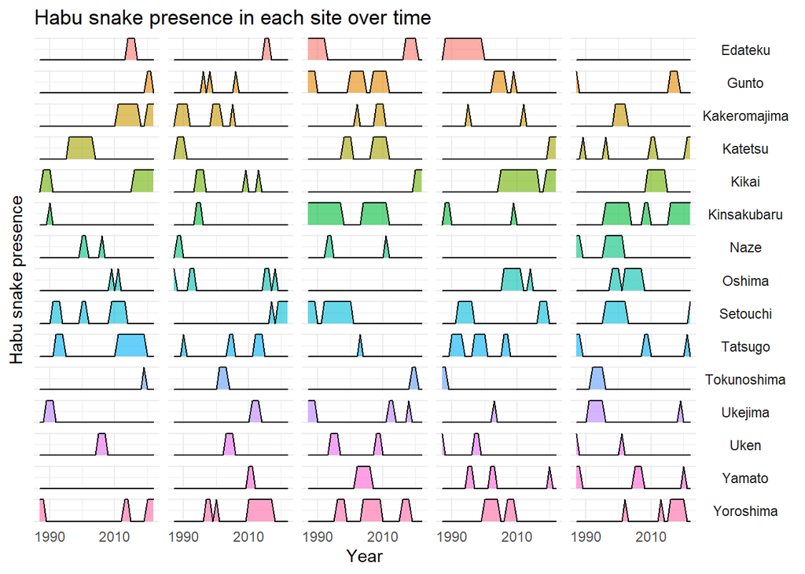

```r
snake_plot <- melt(snake_df, id="site" )

snake_plot$region <- str_split(snake_plot$site, pattern = " ", simplify = TRUE)[,1]
snake_plot$location <- str_split(snake_plot$site, pattern = " ", simplify = TRUE)[,2]

snake_plot$year <- as.numeric(as.character(snake_plot$variable))

ggplot(snake_plot) +
  geom_area(aes(x = year, y = value, fill = region, group = location),
            show.legend = FALSE, alpha = 0.6, colour = "black") +
  labs(x = "Year",
       y = "Habu snake presence",
       fill = "Region",
       title = "Habu snake presence in each site over time") +
  facet_grid(region ~ location) +
  scale_y_continuous(breaks = c(0, 1)) +
  scale_x_continuous(breaks = c(1990, 2010)) +
  theme_bw() +
  theme_minimal() +
  theme(axis.text.y = element_blank(),
        axis.ticks.y = element_blank(),
        strip.text.x = element_blank(),
        strip.text.y = element_text(angle = 360))
```

## Forest area

Forest area is constant throughout the years, but varies within sites ($i$) across regions:

$Area_i = Uniform(2, 100)$

### Simulation

```r
set.seed(666)
# Array with [Year, Site, Region]
forest <- array(0, dim = c(nrow = n_year, ncol = n_site, n_region))

for(s in 1:n_site){
  for(r in 1:n_region){
    forest[, s, r] <- round(runif(1, 2, 100), digits = 1)
  }
}
```

### Data

```r
forest_df <- as.data.frame(t(as.data.frame(forest)))

rownames(forest_df)[1:length(seq_names)] <- seq_names
colnames(forest_df) <- colnames(human_df[,-37])

forest_df$site <- factor(rownames(forest_df))
forest_df
```

|  | 1987 | 1988 | 1989 | 1990 | 1991 | 1992 | 1993 | 1994 | 1995 | 1996 | 1997 | 1998 | 1999 | 2000 | 2001 | 2002 | 2003 | 2004 | 2005 | 2006 | 2007 | 2008 | 2009 | 2010 | 2011 | 2012 | 2013 | 2014 | 2015 | … |
| --- | --- | --- | --- | --- | --- | --- | --- | --- | --- | --- | --- | --- | --- | --- | --- | --- | --- | --- | --- | --- | --- | --- | --- | --- | --- | --- | --- | --- | --- | --- |
| Edateku a | 77.9 | 77.9 | 77.9 | 77.9 | 77.9 | 77.9 | 77.9 | 77.9 | 77.9 | 77.9 | 77.9 | 77.9 | 77.9 | 77.9 | 77.9 | 77.9 | 77.9 | 77.9 | 77.9 | 77.9 | 77.9 | 77.9 | 77.9 | 77.9 | 77.9 | 77.9 | 77.9 | 77.9 | 77.9 | … |
| Edateku b | 81.5 | 81.5 | 81.5 | 81.5 | 81.5 | 81.5 | 81.5 | 81.5 | 81.5 | 81.5 | 81.5 | 81.5 | 81.5 | 81.5 | 81.5 | 81.5 | 81.5 | 81.5 | 81.5 | 81.5 | 81.5 | 81.5 | 81.5 | 81.5 | 81.5 | 81.5 | 81.5 | 81.5 | 81.5 | … |
| Edateku c | 48.0 | 48.0 | 48.0 | 48.0 | 48.0 | 48.0 | 48.0 | 48.0 | 48.0 | 48.0 | 48.0 | 48.0 | 48.0 | 48.0 | 48.0 | 48.0 | 48.0 | 48.0 | 48.0 | 48.0 | 48.0 | 48.0 | 48.0 | 48.0 | 48.0 | 48.0 | 48.0 | 48.0 | 48.0 | … |
| Edateku d | 74.4 | 74.4 | 74.4 | 74.4 | 74.4 | 74.4 | 74.4 | 74.4 | 74.4 | 74.4 | 74.4 | 74.4 | 74.4 | 74.4 | 74.4 | 74.4 | 74.4 | 74.4 | 74.4 | 74.4 | 74.4 | 74.4 | 74.4 | 74.4 | 74.4 | 74.4 | 74.4 | 74.4 | 74.4 | … |
| Edateku e | 77.9 | 77.9 | 77.9 | 77.9 | 77.9 | 77.9 | 77.9 | 77.9 | 77.9 | 77.9 | 77.9 | 77.9 | 77.9 | 77.9 | 77.9 | 77.9 | 77.9 | 77.9 | 77.9 | 77.9 | 77.9 | 77.9 | 77.9 | 77.9 | 77.9 | 77.9 | 77.9 | 77.9 | 77.9 | … |
| Oshima a | 21.3 | 21.3 | 21.3 | 21.3 | 21.3 | 21.3 | 21.3 | 21.3 | 21.3 | 21.3 | 21.3 | 21.3 | 21.3 | 21.3 | 21.3 | 21.3 | 21.3 | 21.3 | 21.3 | 21.3 | 21.3 | 21.3 | 21.3 | 21.3 | 21.3 | 21.3 | 21.3 | 21.3 | 21.3 | … |
| Oshima b | 5.6 | 5.6 | 5.6 | 5.6 | 5.6 | 5.6 | 5.6 | 5.6 | 5.6 | 5.6 | 5.6 | 5.6 | 5.6 | 5.6 | 5.6 | 5.6 | 5.6 | 5.6 | 5.6 | 5.6 | 5.6 | 5.6 | 5.6 | 5.6 | 5.6 | 5.6 | 5.6 | 5.6 | 5.6 | … |
| Oshima c | 41.0 | 41.0 | 41.0 | 41.0 | 41.0 | 41.0 | 41.0 | 41.0 | 41.0 | 41.0 | 41.0 | 41.0 | 41.0 | 41.0 | 41.0 | 41.0 | 41.0 | 41.0 | 41.0 | 41.0 | 41.0 | 41.0 | 41.0 | 41.0 | 41.0 | 41.0 | 41.0 | 41.0 | 41.0 | … |
| Oshima d | 39.0 | 39.0 | 39.0 | 39.0 | 39.0 | 39.0 | 39.0 | 39.0 | 39.0 | 39.0 | 39.0 | 39.0 | 39.0 | 39.0 | 39.0 | 39.0 | 39.0 | 39.0 | 39.0 | 39.0 | 39.0 | 39.0 | 39.0 | 39.0 | 39.0 | 39.0 | 39.0 | 39.0 | 39.0 | … |
| Oshima e | 81.6 | 81.6 | 81.6 | 81.6 | 81.6 | 81.6 | 81.6 | 81.6 | 81.6 | 81.6 | 81.6 | 81.6 | 81.6 | 81.6 | 81.6 | 81.6 | 81.6 | 81.6 | 81.6 | 81.6 | 81.6 | 81.6 | 81.6 | 81.6 | 81.6 | 81.6 | 81.6 | 81.6 | 81.6 | … |

[output cut: 65 more lines]

### Figure

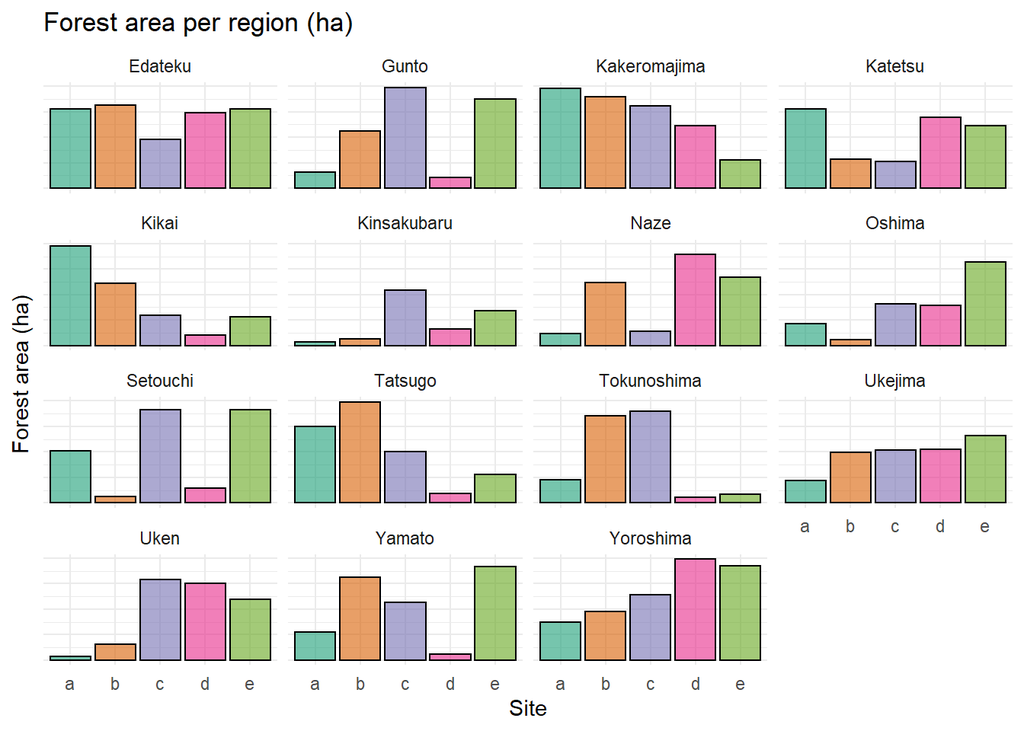

```r
forest_plot <- melt(forest_df, id="site" )

forest_plot$region <- str_split(forest_plot$site, pattern = " ", simplify = TRUE)[,1]
forest_plot$location <- str_split(forest_plot$site, pattern = " ", simplify = TRUE)[,2]

forest_plot$year <- as.numeric(as.character(forest_plot$variable))

forest_plot <- forest_plot %>%
  group_by(region, location) %>%
  summarise(forest_area = mean(value))

ggplot(forest_plot) +
  geom_col(aes(x = location, y = forest_area, fill = location),
            show.legend = FALSE, alpha = 0.6, colour = "black") +
  labs(x = "Site",
       y = "Forest area (ha)",
       fill = "Region",
       title = "Forest area per region (ha)") +
  facet_wrap(~ region) +
  scale_fill_brewer(palette = "Dark2") +
  theme_bw() +
  theme_minimal() +
  theme(axis.text.y = element_blank(),
        axis.ticks.y = element_blank(),
        strip.text.y = element_text(angle = 360))
```

## Precipitation

Rainfall is also temporally autocorrelated, and is generated from a log normal distribution:

$Rain_{i,1} = logNormal(\mu_{i,1},0.5), log(mu_{i,1}) = 5$

$Rain_{i,t} = logNormal(\mu_{i,0.5})$

$log(\mu_{i,t}) = 5 + Rain_{i,t-1} \times 0.35$

However, if rain ever went over 3500, then it would be reset using $Rain_{i,1} = logNormal(\mu_{i,1},0.5), log(mu_{i,1}) = 5$.

### Simulation

```r
set.seed(666)
# Array with [Year, Site, Region]
rain <- array(0, dim = c(nrow = n_year, ncol = n_site, n_region))

rain[1, , ] <- rlnorm(n = n_site * n_region, mean = 5, sd = 0.5)

for(t in 2:n_year){
  for(i in 1:n_region){
    for(s in 1:n_site) {
      rain[t, s, i] <- rlnorm(n = 1, mean = 5 + rain[t-1, s, i] * 0.35, sd = 0.5)
      rain[t, s, i] <- ifelse(rain[t, s, i] > 3500, rlnorm(n = 1, mean = 5, sd = 0.5), rain[t, s, i])
    }
  }
}
```

### Data

```r
rain_df <- as.data.frame(t(as.data.frame(rain)))

rownames(rain_df)[1:length(seq_names)] <- seq_names
colnames(rain_df) <- colnames(human_df[,-37])

rain_df$site <- factor(rownames(rain_df))
rain_df
```

|  | 1987 | 1988 | 1989 | 1990 | 1991 | 1992 | 1993 | 1994 | 1995 | 1996 | 1997 | 1998 | 1999 | 2000 | 2001 | 2002 | 2003 | 2004 | 2005 | 2006 | 2007 | 2008 | 2009 | 2010 | 2011 | 2012 | 2013 | 2014 | 2015 | … |
| --- | --- | --- | --- | --- | --- | --- | --- | --- | --- | --- | --- | --- | --- | --- | --- | --- | --- | --- | --- | --- | --- | --- | --- | --- | --- | --- | --- | --- | --- | --- |
| Edateku a | 216.29766 | 100.18933 | 315.57325 | 105.74529 | 109.92089 | 182.14654 | 182.64657 | 151.65133 | 604.24732 | 292.24007 | 126.54029 | 346.64921 | 214.65698 | 288.63229 | 143.79286 | 170.40386 | 168.98918 | 44.30843 | 203.26780 | 166.33892 | 134.20089 | 147.07334 | 179.85944 | 661.39595 | 141.36607 | 159.30128 | 362.51643 | 134.12750 | 131.14340 | … |
| Edateku b | 406.33475 | 108.43711 | 147.40796 | 197.28398 | 207.40953 | 117.70225 | 114.65527 | 139.04720 | 290.88799 | 119.94709 | 283.34078 | 345.31176 | 119.16258 | 139.24677 | 218.26289 | 215.18546 | 201.79898 | 90.04312 | 249.12908 | 193.71462 | 258.89385 | 167.97568 | 68.88933 | 145.39781 | 77.68665 | 95.77155 | 148.58321 | 369.12717 | 97.02330 | … |
| Edateku c | 124.26704 | 312.56297 | 167.12355 | 126.19020 | 185.09293 | 205.82246 | 141.15384 | 111.67548 | 82.15541 | 178.92052 | 102.30918 | 163.73709 | 79.88719 | 118.99191 | 75.46920 | 88.00865 | 129.74996 | 97.58733 | 206.10326 | 64.81576 | 223.12759 | 116.76024 | 76.58118 | 268.71257 | 162.94610 | 93.92839 | 80.53829 | 175.69178 | 240.00122 | … |
| Edateku d | 409.15085 | 125.93927 | 218.08095 | 154.37108 | 91.96903 | 138.88741 | 149.14545 | 241.00924 | 223.05182 | 147.78121 | 98.41746 | 132.56496 | 72.98010 | 316.84392 | 104.17719 | 169.70951 | 204.59454 | 211.06739 | 151.33641 | 158.49889 | 201.52859 | 208.38488 | 114.70002 | 238.03979 | 144.03812 | 84.54118 | 61.63947 | 208.61455 | 61.68872 | … |
| Edateku e | 48.98738 | 147.34955 | 186.45440 | 52.20134 | 169.47576 | 141.12835 | 91.85982 | 198.72070 | 70.44059 | 73.95058 | 81.04780 | 195.98634 | 350.41353 | 215.14446 | 332.71381 | 125.98252 | 95.83547 | 186.61769 | 287.42882 | 109.24840 | 303.05490 | 184.24875 | 48.71964 | 168.84130 | 204.54648 | 133.19655 | 86.68428 | 61.62977 | 120.46878 | … |
| Oshima a | 216.84831 | 181.55460 | 66.35719 | 176.13181 | 133.67953 | 135.37419 | 123.41006 | 144.98761 | 93.88550 | 262.39693 | 174.84429 | 103.28552 | 239.68342 | 123.88947 | 155.74465 | 144.61499 | 147.66192 | 170.43531 | 151.90510 | 186.33124 | 145.80553 | 299.89962 | 50.98590 | 181.21298 | 104.41851 | 285.47301 | 143.10587 | 509.51504 | 292.38105 | … |
| Oshima b | 77.23922 | 158.96286 | 83.75669 | 122.45109 | 142.49787 | 139.50369 | 199.40418 | 94.36324 | 49.29635 | 226.80934 | 45.64493 | 92.77640 | 82.14785 | 110.50689 | 112.75509 | 148.97629 | 97.93442 | 278.85074 | 346.74269 | 145.39642 | 147.73332 | 245.17248 | 150.46976 | 122.74232 | 136.93725 | 140.04853 | 282.17801 | 75.92460 | 141.50490 | … |
| Oshima c | 99.35907 | 116.33897 | 205.45987 | 146.94659 | 112.04532 | 196.65875 | 88.66253 | 92.47936 | 92.58495 | 179.95518 | 212.18319 | 423.74199 | 59.85359 | 75.19417 | 87.73946 | 191.34406 | 120.32739 | 196.29308 | 86.82996 | 131.21530 | 241.05967 | 51.76442 | 131.45145 | 117.78989 | 151.68895 | 196.71807 | 58.00309 | 67.56135 | 215.22429 | … |
| Oshima d | 60.57484 | 174.20633 | 86.19711 | 52.84311 | 112.59694 | 172.53440 | 489.53415 | 182.93882 | 84.22425 | 122.03469 | 111.59392 | 91.56264 | 294.33365 | 174.47111 | 182.46088 | 119.94742 | 191.17032 | 136.42660 | 345.02377 | 110.08378 | 118.73849 | 238.43069 | 189.24375 | 453.57332 | 118.94392 | 65.96321 | 152.07553 | 176.07439 | 410.61935 | … |
| Oshima e | 145.32662 | 88.19966 | 129.76384 | 248.65090 | 289.96835 | 150.83370 | 164.41408 | 187.19577 | 377.70339 | 190.66382 | 112.96918 | 72.77848 | 63.67272 | 306.64157 | 207.01860 | 71.06347 | 156.68080 | 52.27834 | 67.83079 | 189.32099 | 262.31527 | 246.83845 | 104.90886 | 42.93697 | 220.04623 | 136.84580 | 181.97786 | 100.32998 | 51.51427 | … |

[output cut: 65 more lines]

### Figure

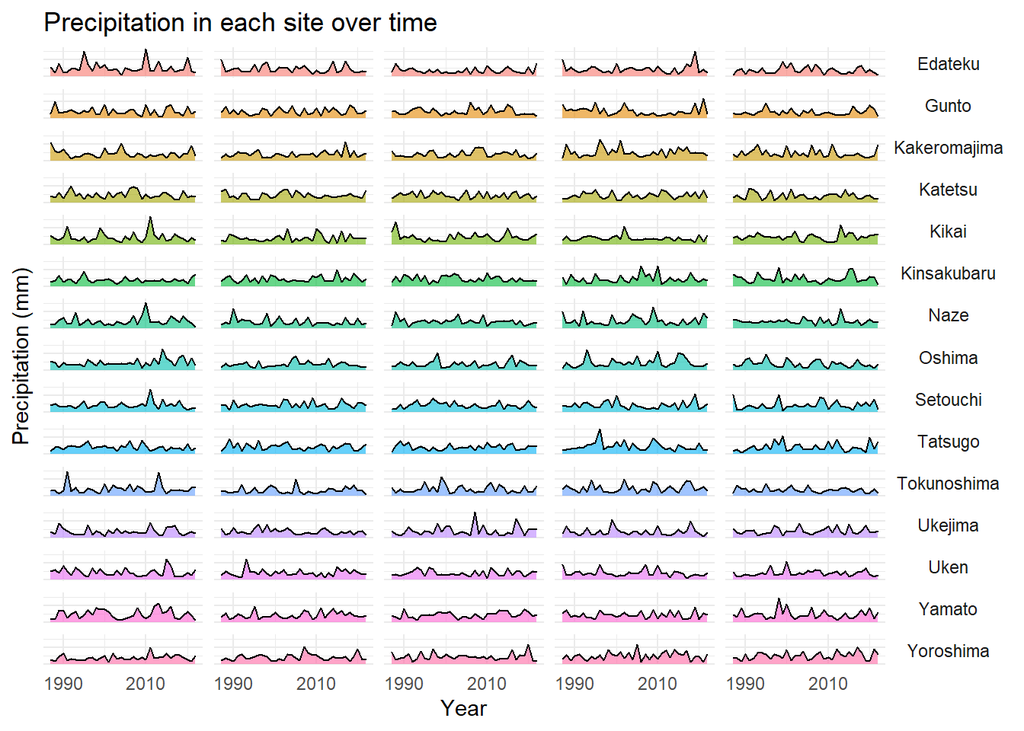

```r
rain_plot <- melt(rain_df, id="site" )

rain_plot$region <- str_split(rain_plot$site, pattern = " ", simplify = TRUE)[,1]
rain_plot$location <- str_split(rain_plot$site, pattern = " ", simplify = TRUE)[,2]

rain_plot$year <- as.numeric(as.character(rain_plot$variable))

ggplot(rain_plot) +
  geom_area(aes(x = year, y = value, fill = region, group = location),
            show.legend = FALSE, alpha = 0.6, colour = "black") +
  labs(x = "Year",
       y = "Precipitation (mm)",
       fill = "Region",
       title = "Precipitation in each site over time") +
  facet_grid(region ~ location) +
  scale_y_continuous(n.breaks = 3) +
  scale_x_continuous(breaks = c(1990, 2010)) +
  theme_bw() +
  theme_minimal() +
  theme(axis.text.y = element_blank(),
        axis.ticks.y = element_blank(),
        strip.text.x = element_blank(),
        strip.text.y = element_text(angle = 360))
```

## Sniffer dogs

Sniffer dog useage increases over time and is generated from a binomial distribution for each site over time:

$Dog_{i,t} = binomial(p_{i,t})$

$logit(p_{i,t}) = -4 + Years_{i,t-1} \times 0.2$

### Simulation

```r
set.seed(666)
# Array with [Year, Site, Region]
dog <- array(0, dim = c(nrow = n_year, ncol = n_site, n_region))

dog[1, , ] <- rbinom(n = n_site * n_region, size = 1, prob = 0.01)

for(t in 2:n_year){
  for(i in 1:n_region){
    for(s in 1:n_site) {
      dog[t, s, i] <- rbinom(1, 1, prob = plogis(-4 + t * 0.2))
    }
  }
}
```

### Data

```r
dog_df <- as.data.frame(t(as.data.frame(dog)))

rownames(dog_df)[1:length(seq_names)] <- seq_names
colnames(dog_df) <- colnames(human_df[,-37])

dog_df$site <- factor(rownames(dog_df))
dog_df
```

|  | 1987 | 1988 | 1989 | 1990 | 1991 | 1992 | 1993 | 1994 | 1995 | 1996 | 1997 | 1998 | 1999 | 2000 | 2001 | 2002 | 2003 | 2004 | 2005 | 2006 | 2007 | 2008 | 2009 | 2010 | 2011 | 2012 | 2013 | 2014 | 2015 | … |
| --- | --- | --- | --- | --- | --- | --- | --- | --- | --- | --- | --- | --- | --- | --- | --- | --- | --- | --- | --- | --- | --- | --- | --- | --- | --- | --- | --- | --- | --- | --- |
| Edateku a | 0 | 0 | 0 | 0 | 0 | 0 | 0 | 0 | 0 | 0 | 0 | 0 | 0 | 0 | 1 | 0 | 0 | 0 | 0 | 0 | 0 | 0 | 1 | 1 | 0 | 0 | 1 | 0 | 1 | … |
| Edateku b | 0 | 0 | 0 | 0 | 0 | 0 | 0 | 0 | 0 | 0 | 0 | 1 | 0 | 0 | 0 | 1 | 1 | 0 | 1 | 1 | 1 | 1 | 1 | 1 | 1 | 0 | 1 | 1 | 0 | … |
| Edateku c | 0 | 0 | 0 | 0 | 0 | 0 | 1 | 0 | 0 | 0 | 0 | 0 | 0 | 0 | 0 | 1 | 1 | 1 | 1 | 1 | 0 | 1 | 0 | 0 | 1 | 1 | 1 | 1 | 0 | … |
| Edateku d | 0 | 1 | 0 | 0 | 0 | 0 | 0 | 0 | 0 | 0 | 0 | 0 | 0 | 1 | 0 | 0 | 0 | 0 | 0 | 1 | 0 | 1 | 1 | 1 | 1 | 1 | 1 | 1 | 1 | … |
| Edateku e | 0 | 0 | 0 | 0 | 0 | 0 | 0 | 0 | 0 | 0 | 0 | 0 | 0 | 0 | 0 | 0 | 0 | 0 | 1 | 1 | 0 | 1 | 1 | 1 | 0 | 1 | 1 | 1 | 1 | … |
| Oshima a | 0 | 0 | 0 | 0 | 0 | 0 | 0 | 0 | 0 | 0 | 0 | 0 | 0 | 1 | 0 | 1 | 0 | 1 | 0 | 0 | 1 | 1 | 0 | 0 | 0 | 0 | 1 | 0 | 0 | … |
| Oshima b | 0 | 0 | 0 | 0 | 0 | 1 | 0 | 0 | 0 | 0 | 0 | 0 | 0 | 0 | 1 | 0 | 0 | 0 | 0 | 1 | 1 | 0 | 1 | 1 | 1 | 1 | 1 | 1 | 0 | … |
| Oshima c | 0 | 0 | 0 | 0 | 0 | 0 | 0 | 0 | 0 | 0 | 0 | 1 | 0 | 1 | 0 | 0 | 0 | 1 | 0 | 0 | 0 | 1 | 1 | 1 | 1 | 1 | 1 | 1 | 1 | … |
| Oshima d | 0 | 0 | 0 | 0 | 0 | 0 | 0 | 0 | 0 | 0 | 0 | 0 | 0 | 0 | 0 | 0 | 0 | 0 | 0 | 1 | 1 | 1 | 1 | 1 | 1 | 0 | 1 | 0 | 1 | … |
| Oshima e | 0 | 0 | 0 | 0 | 0 | 0 | 0 | 0 | 0 | 1 | 0 | 1 | 0 | 0 | 1 | 1 | 0 | 0 | 0 | 1 | 1 | 0 | 0 | 0 | 1 | 1 | 1 | 1 | 1 | … |

[output cut: 65 more lines]

### Figure

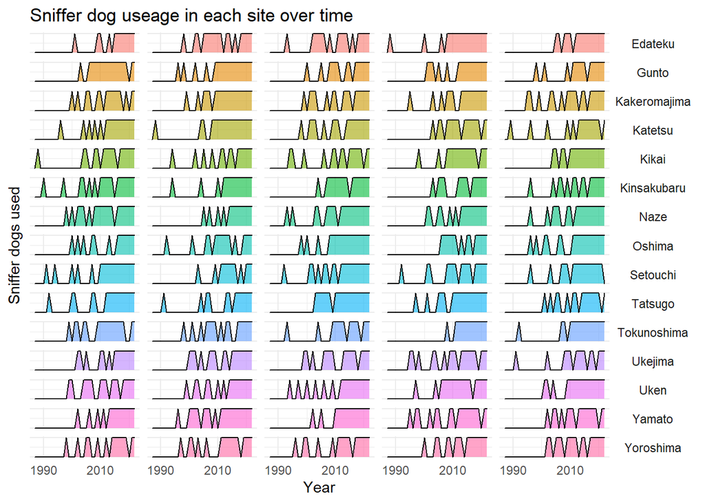

```r
dog_plot <- melt(dog_df, id="site" )

dog_plot$region <- str_split(dog_plot$site, pattern = " ", simplify = TRUE)[,1]
dog_plot$location <- str_split(dog_plot$site, pattern = " ", simplify = TRUE)[,2]

dog_plot$year <- as.numeric(as.character(dog_plot$variable))

ggplot(dog_plot) +
  geom_area(aes(x = year, y = value, fill = region, group = location),
            show.legend = FALSE, alpha = 0.6, colour = "black") +
  labs(x = "Year",
       y = "Sniffer dogs used",
       fill = "Region",
       title = "Sniffer dog useage in each site over time") +
  facet_grid(region ~ location) +
  scale_y_continuous(breaks = c(0, 1)) +
  scale_x_continuous(breaks = c(1990, 2010)) +
  theme_bw() +
  theme_minimal() +
  theme(axis.text.y = element_blank(),
        axis.ticks.y = element_blank(),
        strip.text.x = element_blank(),
        strip.text.y = element_text(angle = 360))
```

# Occupancy simulation

## Initial occupancy

Initial occupancy is a constant 75% chance.

$\psi_1 = Binomial(\Xi)$

$logit(\Xi) = \rho$

$\rho = 1.1$

```r
set.seed(666)

xi = 1.1

psi <- plogis(xi)

# Use probability and draw from binomial distribution to determine presence/absence
occupancy[1, , ] <- rbinom(length(occupancy[1, , ]), size = 1, prob = psi)
```

## Dynamic occupancy

Colonisation probability varies in each site ($i$) and in each year ($t$) according to snake (negative) and rabbit (positive) presence.

$logit(\gamma_{i,t}) = \eta_0 + \eta_1 \times Snake_{i,t} + \eta_2 \times Rabbit_{i,t}$

$\eta_0 = -1, \eta_1 = -1, \eta_2 = 2$

Extinction probability:

$logit(\epsilon_{i,t}) = \zeta_0 + \zeta_1 \times Buster_{i,t} + \zeta_2 \times Forest_{i,t} + \zeta_3 \times Human_{i,t}$

Occupancy:

Generated from a binomial distribution with a conditional statement:

Keep in mind that initial occupancy has already been resolved (see above), so $t$ here is from the second occasion onwards.

$\Pi_{i,t} \sim Binomial(\theta_{i,t})$

where:

$\Pi$ is the occupancy state (i.e., occupied or vacant).

$\theta$ is the probability for a site to be occupied.

$\gamma$ and $\epsilon$ are as above (colonisation and extinction probabilities).

```r
# gamma parameters
eta0 = -1
eta1 = -1
eta2 = 2

# extinction parameters
zeta0 = -1.5  # larger values decrease extinction (intercept)
zeta1 = 5     # larger values increase extinction (mongoose busters)
zeta2 = -0.02 # larger values decrease extinction (smaller forests bad)
zeta3 = -0.03 # larger values decrease extinction (closer humans bad)

for(t in 2:n_year) {
  # Probability of colonization
  colonise_p[t, , ] <- plogis(eta0 + eta1 * snake[t, , ] + eta2 * rabbit[t, , ])

  # Probability of extinction
  extinct_p[t, , ] <- plogis(zeta0 + zeta1 * buster[t, , ] + zeta2 * forest[t, , ] + zeta3 * human[t, , ])

  # Probability to be present
  # The ifelse can be read as:
    # If the site is unoccupied, what is the prob is was colonised?
    # If the sire was occupied, what is the prob that it *failed* to go extinct?
  presence_p[t, , ] <- ifelse(occupancy[t - 1, , ] == 0, colonise_p[t, , ], 1 - extinct_p[t, , ])

  # Actual presence in subsequent years
  occupancy[t, , ] <- rbinom(length(presence_p[t, , ]), size = 1, prob = presence_p[t, , ])
}
```

## Detection

### Survey times

Below I determine in which years did surveying take place. This could be every year, or every 5 years. Whichever we deem most appropriate. Given that the simulation is currently over a very long period of time, I have surveys occur every two years, though this may change. Check the code to make sure I haven’t changed the code, but not updated this text (see the: `survey_times <- seq(1, n_year, by = XXX`, where `XXX` is how often the surveys occur).

I also decide here how many surveys occur each year.

```r
survey_times <- seq(1, n_year, by = 2)
n_survey <- 3
```

### Detection probability

Detection probability is increased by the presence of sniffer dogs. The relationship is:

$logit(p_{i,t, s}) = \delta_0 + \delta_1 \times Dog_{i,t,s}$

where:

$p$ is the probability to detect mongoose in site $i$, in year $t$, and in survey $s$

$\delta_0 = 0.85$

$\delta_1 = 1.5$

```r
set.seed(666)

detect_p <- array(0, dim = c(nrow = length(survey_times), ncol = n_site, n_region))
rownames(detect_p) <- 1986 + survey_times

# Parameters
delta_0 = 0.85
delta_1 = 1.5

# Detection probability is 0 + 0.01 * rainfall

for(j in 1:n_region){
  for (i in 1:length(survey_times)) {
    detect_p[i, , j] <- plogis(delta_0 + delta_1 * dog[i, , j])
  }
}
```

### Detections

Using the probability of detection, this is used to determine if mongoose were actually detected or not in each survey. Note that the detection probability is multiplied by the occupancy state (meaning that if there were no mongoose, you cannot detect them - no false positives).

$Y_{i,t,s} \sim Binomial(\Pi_{i,t,s} \times p_{i,t,s})$

where:

$Y$ is detection of mongoose {0,1} (and forms the encounter histories),

and $\Pi$ is as above (mongoose present or absent, {0,1}).

```r
# Extract the true occupancies for survey times (redundant unless surveys do not occur every year)
occupancy_survey <- occupancy[survey_times, , ]

# Array with [Sampling year, Site, Region]
detections <- array(0, dim = c(nrow = length(survey_times) * n_survey, ncol = n_site, n_region))

# Year as row name
rownames(detections) <- rep(1986 + survey_times, each = 3)

for(j in 1:n_region) {
  for (i in 1:n_site) {
    detections[, i, j] <- rbinom(n = length(survey_times) * n_survey,
                                 size = 1,
                                 prob = rep(detect_p[, i, j], each = n_survey) * rep(occupancy_survey[, i, j], each = n_survey))
  }
}
```

# Encounter histories

Note that the years are replicated for each survey (so `1897` is the first survey and `1987.1` is the second survey).

```r
detections_df <- as.data.frame(t(as.data.frame(detections)))

rownames(detections_df)[1:length(seq_names)] <- seq_names

detections_df$site <- factor(rownames(detections_df))
colnames(detections_df) <- gsub("X", "", colnames(detections_df))

detections_df
```

|  | 1987 | 1987.1 | 1987.2 | 1989 | 1989.1 | 1989.2 | 1991 | 1991.1 | 1991.2 | 1993 | 1993.1 | 1993.2 | 1995 | 1995.1 | 1995.2 | 1997 | 1997.1 | 1997.2 | 1999 | 1999.1 | 1999.2 | 2001 | 2001.1 | 2001.2 | 2003 | 2003.1 | 2003.2 | 2005 | 2005.1 | … |
| --- | --- | --- | --- | --- | --- | --- | --- | --- | --- | --- | --- | --- | --- | --- | --- | --- | --- | --- | --- | --- | --- | --- | --- | --- | --- | --- | --- | --- | --- | --- |
| Edateku a | 0 | 0 | 0 | 0 | 1 | 0 | 1 | 1 | 0 | 0 | 1 | 1 | 1 | 0 | 1 | 1 | 1 | 1 | 0 | 1 | 0 | 1 | 1 | 0 | 1 | 1 | 1 | 0 | 1 | … |
| Edateku b | 1 | 0 | 0 | 0 | 1 | 1 | 1 | 0 | 1 | 1 | 1 | 0 | 1 | 1 | 1 | 0 | 1 | 1 | 0 | 0 | 1 | 1 | 0 | 1 | 1 | 0 | 1 | 0 | 1 | … |
| Edateku c | 0 | 0 | 0 | 0 | 0 | 0 | 0 | 0 | 0 | 0 | 0 | 0 | 1 | 1 | 1 | 1 | 1 | 1 | 1 | 1 | 1 | 0 | 1 | 1 | 0 | 1 | 1 | 0 | 1 | … |
| Edateku d | 1 | 1 | 1 | 0 | 0 | 0 | 0 | 0 | 0 | 0 | 0 | 0 | 0 | 0 | 0 | 0 | 0 | 0 | 0 | 0 | 0 | 1 | 0 | 1 | 1 | 0 | 1 | 1 | 1 | … |
| Edateku e | 1 | 1 | 0 | 1 | 1 | 1 | 1 | 0 | 1 | 0 | 0 | 1 | 0 | 1 | 1 | 1 | 0 | 0 | 1 | 1 | 1 | 0 | 1 | 1 | 0 | 1 | 0 | 1 | 1 | … |
| Oshima a | 1 | 1 | 1 | 1 | 0 | 1 | 1 | 1 | 1 | 0 | 1 | 0 | 1 | 1 | 1 | 0 | 1 | 1 | 0 | 0 | 1 | 1 | 1 | 1 | 1 | 1 | 1 | 0 | 0 | … |
| Oshima b | 0 | 0 | 0 | 1 | 1 | 1 | 1 | 0 | 0 | 0 | 0 | 0 | 0 | 0 | 0 | 1 | 1 | 1 | 1 | 0 | 0 | 0 | 0 | 0 | 0 | 0 | 0 | 0 | 0 | … |
| Oshima c | 1 | 1 | 0 | 1 | 0 | 1 | 1 | 1 | 1 | 0 | 1 | 0 | 1 | 1 | 1 | 0 | 1 | 0 | 0 | 0 | 0 | 0 | 0 | 0 | 0 | 0 | 0 | 0 | 0 | … |
| Oshima d | 0 | 0 | 1 | 1 | 0 | 0 | 0 | 0 | 1 | 0 | 1 | 1 | 1 | 0 | 1 | 0 | 0 | 0 | 0 | 0 | 0 | 0 | 0 | 0 | 0 | 0 | 0 | 0 | 0 | … |
| Oshima e | 1 | 1 | 0 | 1 | 0 | 1 | 1 | 1 | 1 | 0 | 0 | 0 | 1 | 0 | 0 | 1 | 0 | 1 | 1 | 0 | 0 | 1 | 1 | 0 | 0 | 0 | 0 | 0 | 0 | … |

[output cut: 65 more lines]

# Figures

## Initial occupancy (outcome)

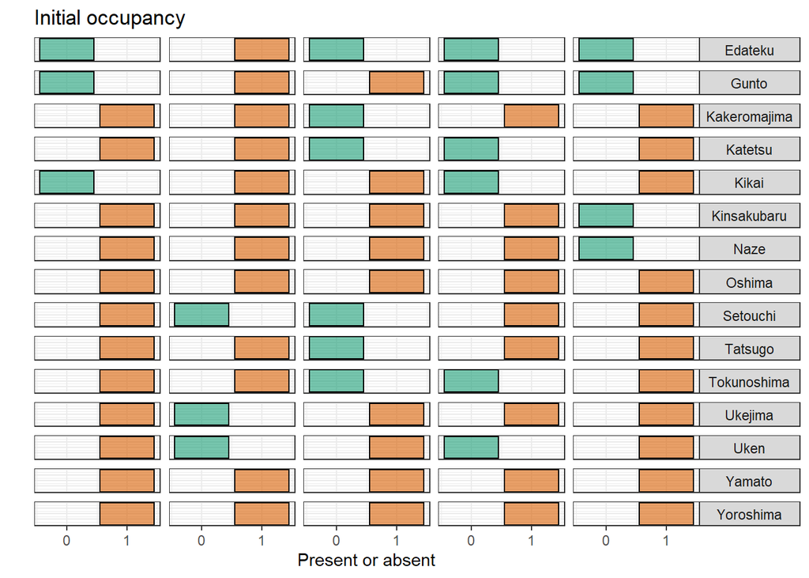

```r
psi_plot <- as.data.frame(t(as.data.frame(occupancy[1, , ])))

psi_plot <- melt(psi_plot)

psi_plot$variable <- seq_names

psi_plot$region <- str_split(psi_plot$variable, pattern = " ", simplify = TRUE)[,1]
psi_plot$location <- str_split(psi_plot$variable, pattern = " ", simplify = TRUE)[,2]


ggplot(psi_plot) +
  geom_bar(aes(x = value, fill = factor(value)),
            show.legend = FALSE, alpha = 0.6, colour = "black") +
  labs(x = "Present or absent",
       y = "",
       title = "Initial occupancy",
       fill = "Region") +
  scale_x_continuous(breaks = c(0, 1)) +
  scale_fill_brewer(palette = "Dark2") +
  facet_grid(region ~ location) +
  theme_bw() +
  theme(axis.text.y = element_blank(),
        axis.ticks.y = element_blank(),
        strip.text.x = element_blank(),
        strip.text.y = element_text(angle = 360))
```

## Colonisation (probability)

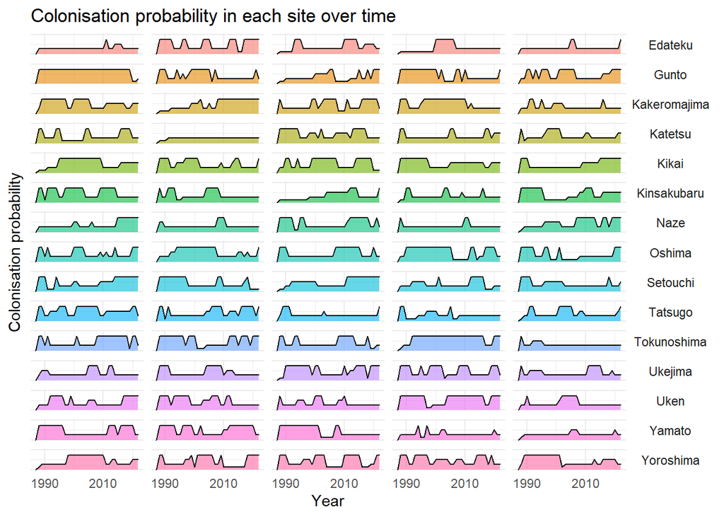

```r
colonise_df <- as.data.frame(t(as.data.frame(colonise_p)))

rownames(colonise_df)[1:length(seq_names)] <- seq_names
colnames(colonise_df) <- colnames(human_df[,-37])

colonise_df$site <- factor(rownames(colonise_df))

colonise_plot <- melt(colonise_df, id="site" )

colonise_plot$region <- str_split(colonise_plot$site, pattern = " ", simplify = TRUE)[,1]
colonise_plot$location <- str_split(colonise_plot$site, pattern = " ", simplify = TRUE)[,2]

colonise_plot$year <- as.numeric(as.character(colonise_plot$variable))

ggplot(colonise_plot) +
  geom_area(aes(x = year, y = value, fill = region, group = location),
            show.legend = FALSE, alpha = 0.6, colour = "black") +
  labs(x = "Year",
       y = "Colonisation probability",
       fill = "Region",
       title = "Colonisation probability in each site over time") +
  facet_grid(region ~ location) +
  scale_y_continuous(breaks = c(0, 1), limits = c(0, 1), labels = scales::percent) +
  scale_x_continuous(breaks = c(1990, 2010)) +
  theme_bw() +
  theme_minimal() +
  theme(axis.text.y = element_blank(),
        axis.ticks.y = element_blank(),
        strip.text.x = element_blank(),
        strip.text.y = element_text(angle = 360))
```

## Extinction (probability)

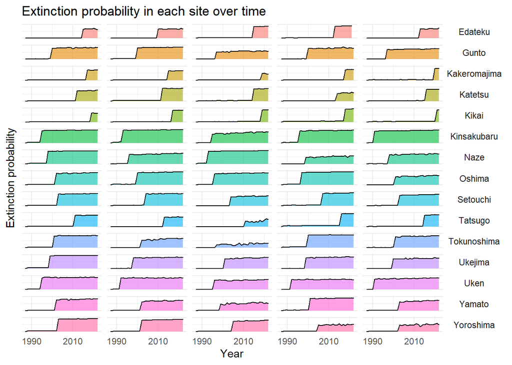

```r
extinct_df <- as.data.frame(t(as.data.frame(extinct_p)))

rownames(extinct_df)[1:length(seq_names)] <- seq_names
colnames(extinct_df) <- colnames(human_df[,-37])

extinct_df$site <- factor(rownames(extinct_df))

extinct_plot <- melt(extinct_df, id="site" )

extinct_plot$region <- str_split(extinct_plot$site, pattern = " ", simplify = TRUE)[,1]
extinct_plot$location <- str_split(extinct_plot$site, pattern = " ", simplify = TRUE)[,2]

extinct_plot$year <- as.numeric(as.character(extinct_plot$variable))

ggplot(extinct_plot) +
  geom_area(aes(x = year, y = value, fill = region, group = location),
            show.legend = FALSE, alpha = 0.6, colour = "black") +
  labs(x = "Year",
       y = "Extinction probability",
       fill = "Region",
       title = "Extinction probability in each site over time") +
  facet_grid(region ~ location) +
  scale_y_continuous(breaks = c(0, 1), limits = c(0, 1), labels = scales::percent) +
  scale_x_continuous(breaks = c(1990, 2010)) +
  theme_bw() +
  theme_minimal() +
  theme(axis.text.y = element_blank(),
        axis.ticks.y = element_blank(),
        strip.text.x = element_blank(),
        strip.text.y = element_text(angle = 360))
```

## Presence (probability)

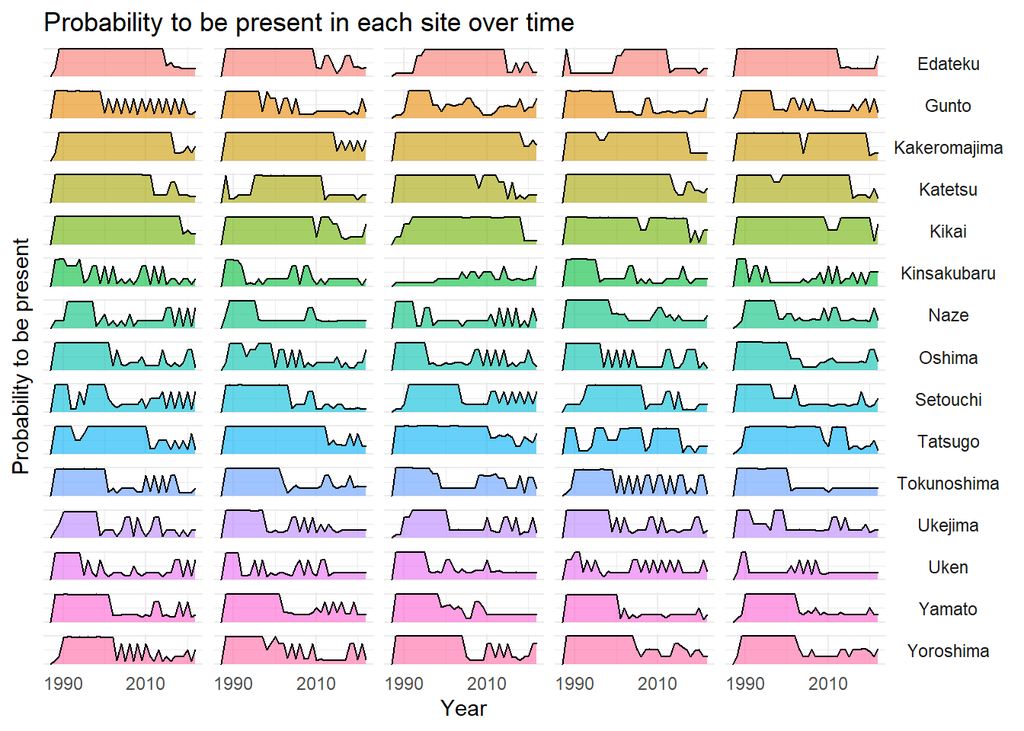

```r
presence_df <- as.data.frame(t(as.data.frame(presence_p)))

rownames(presence_df)[1:length(seq_names)] <- seq_names
colnames(presence_df) <- colnames(human_df[,-37])

presence_df$site <- factor(rownames(presence_df))

presence_plot <- melt(presence_df, id="site" )

presence_plot$region <- str_split(presence_plot$site, pattern = " ", simplify = TRUE)[,1]
presence_plot$location <- str_split(presence_plot$site, pattern = " ", simplify = TRUE)[,2]

presence_plot$year <- as.numeric(as.character(presence_plot$variable))

ggplot(presence_plot) +
  geom_area(aes(x = year, y = value, fill = region, group = location),
            show.legend = FALSE, alpha = 0.6, colour = "black") +
  labs(x = "Year",
       y = "Probability to be present",
       fill = "Region",
       title = "Probability to be present in each site over time") +
  facet_grid(region ~ location) +
  scale_y_continuous(breaks = c(0, 1), limits = c(0, 1), labels = scales::percent) +
  scale_x_continuous(breaks = c(1990, 2010)) +
  theme_bw() +
  theme_minimal() +
  theme(axis.text.y = element_blank(),
        axis.ticks.y = element_blank(),
        strip.text.x = element_blank(),
        strip.text.y = element_text(angle = 360))
```

## Presence (outcome)

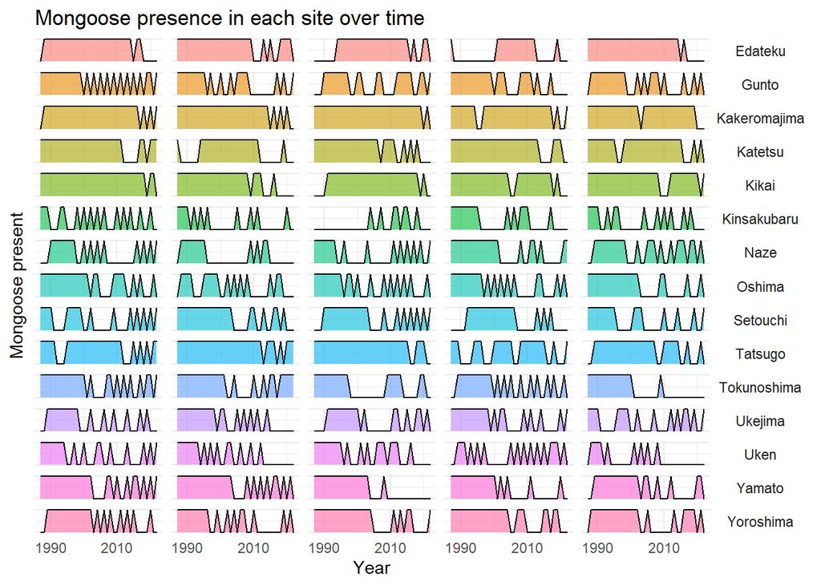

```r
occupancy_df <- as.data.frame(t(as.data.frame(occupancy)))

rownames(occupancy_df)[1:length(seq_names)] <- seq_names
colnames(occupancy_df) <- colnames(human_df[,-37])

occupancy_df$site <- factor(rownames(occupancy_df))

occupancy_plot <- melt(occupancy_df, id="site" )

occupancy_plot$region <- str_split(occupancy_plot$site, pattern = " ", simplify = TRUE)[,1]
occupancy_plot$location <- str_split(occupancy_plot$site, pattern = " ", simplify = TRUE)[,2]

occupancy_plot$year <- as.numeric(as.character(occupancy_plot$variable))

ggplot(occupancy_plot) +
  geom_area(aes(x = year, y = value, fill = region, group = location),
            show.legend = FALSE, alpha = 0.6, colour = "black") +
  labs(x = "Year",
       y = "Mongoose present",
       fill = "Region",
       title = "Mongoose presence in each site over time") +
  facet_grid(region ~ location) +
  scale_y_continuous(breaks = c(0, 1)) +
  scale_x_continuous(breaks = c(1990, 2010)) +
  theme_bw() +
  theme_minimal() +
  theme(axis.text.y = element_blank(),
        axis.ticks.y = element_blank(),
        strip.text.x = element_blank(),
        strip.text.y = element_text(angle = 360))
```

## Detection (probability)

[figure not shown]

```r
detect_p_df <- as.data.frame(t(as.data.frame(detect_p)))

rownames(detect_p_df)[1:length(seq_names)] <- seq_names

detect_p_df$site <- factor(rownames(detect_p_df))

detect_p_plot <- melt(detect_p_df, id="site" )

detect_p_plot$region <- str_split(detect_p_plot$site, pattern = " ", simplify = TRUE)[,1]
detect_p_plot$location <- str_split(detect_p_plot$site, pattern = " ", simplify = TRUE)[,2]

detect_p_plot$year <- as.numeric(as.character(detect_p_plot$variable))

ggplot(detect_p_plot) +
  geom_area(aes(x = year, y = value, fill = region, group = location),
            show.legend = FALSE, alpha = 0.6, colour = "black") +
  labs(x = "Year",
       y = "Probability to be present",
       fill = "Region",
       title = "Probability to be present in each site over time",
       caption = paste("Detection probability ranges from",
                       round(min(detect_p_plot$value), digits = 2),
                       "to",
                       round(max(detect_p_plot$value), digits = 2))) +
  facet_grid(region ~ location) +
  scale_y_continuous(breaks = c(0, 1), limits = c(0, 1), labels = scales::percent) +
  scale_x_continuous(breaks = c(1990, 2010)) +
  theme_bw() +
  theme_minimal() +
  theme(axis.text.y = element_blank(),
        axis.ticks.y = element_blank(),
        strip.text.x = element_blank(),
        strip.text.y = element_text(angle = 360))
```

## Detection (outcome)

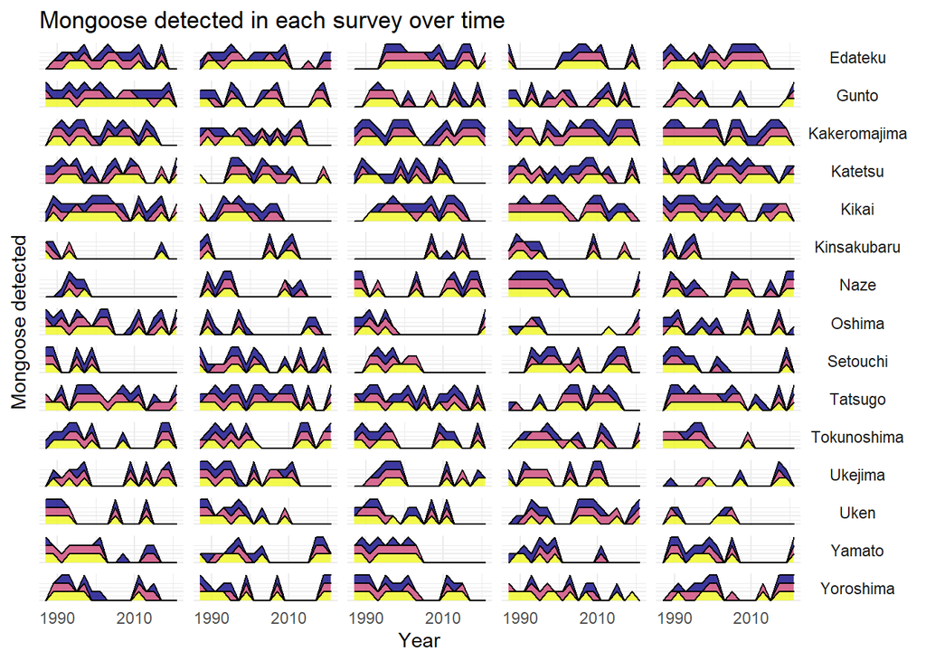

```r
detections_plot <- melt(detections_df, id="site" )

detections_plot$variable <- gsub("X", "", detections_plot$variable)

detections_plot$region <- str_split(detections_plot$site, pattern = " ", simplify = TRUE)[,1]
detections_plot$location <- str_split(detections_plot$site, pattern = " ", simplify = TRUE)[,2]

detections_plot$year <- round(as.numeric(as.character(detections_plot$variable)), digit = 0)

detections_plot$survey <- rep(c(rep(1, times = n_site * n_region),
                                rep(2, times = n_site * n_region),
                                rep(3, times = n_site * n_region)),
                              times = length(survey_times))

ggplot(detections_plot) +
  geom_area(aes(x = year, y = value, fill = factor(survey)),
            show.legend = FALSE, alpha = 0.8, colour = "black") +
  labs(x = "Year",
       y = "Mongoose detected",
       fill = "Survey",
       title = "Mongoose detected in each survey over time",
       colour = "Year") +
  facet_grid(region ~ location) +
  scale_y_continuous(breaks = c(0, 1)) +
  scale_x_continuous(breaks = c(1990, 2010)) +
  #scale_fill_brewer(palette = "Set1") +
  scale_fill_viridis_d(option = "C") +
  theme_bw() +
  theme_minimal() +
  theme(axis.text.y = element_blank(),
        axis.ticks.y = element_blank(),
        strip.text.x = element_blank(),
        strip.text.y = element_text(angle = 360))
```